# Maximum likelihood

This vignette is an introduction to the principle of maximum likelihood, through examples and exercises.

### A coin-tossing example

We start with a coin-tossing example, the simplest possible model that illustrates the principle of maximum likelihood. Suppose $X_i$, $i=1,\ldots,n$, are iid random variables, each with two possible values, 0 or 1, which we can interpret as tails and heads. The probability of the outcome $x \in \{0,1\}$ of a single coin toss is given by
$$P_\theta[X_i = x] = \begin{cases} \theta & x=1 \\ 1-\theta & x=0, \end{cases}$$
where $\theta \in [0,1]$ is a parameter. It is convenient to write this as
$$P_\theta[X_i = x] = \theta^x (1-\theta)^{1-x}.$$

> Exercise: verify that the two previous equations give the same expression for $P_\theta[X_i = x]$.

Now let $X = (X_1,\ldots,X_n)$, a random vector of $n$ coin tosses. Then for each vector $x=(x_1,\ldots,x_n) \in \{0,1\}^n$, a possible outcome of a sequence of $n$ coin tosses,
$$P_\theta[X=x] = \prod_{i=1}^n \theta^{x_i} (1-\theta)^{1-x_i} = \theta^{n_1}(1-\theta)^{n_0},$$
where $n_1$ is the number of times $x_i = 1$ occurs and $n_0$ is the number of times $x_i = 0$ occurs.

### Likelihood, log-likelihood, score and Hessian functions

There are two ways to look at the expression $\theta^{n_1}(1-\theta)^{n_0}$.

1. We can think of it as a function of $x$ for a fixed value of the parameter $\theta$. As such, it gives the probabilities of all possible realizations of $n$ coin tosses at that value of $\theta$; some values of $x$ are more probable than others.
2. Alternatively, we can think of it as a function of $\theta$ for a fixed value $x$ of a sequence of $n$ coin tosses. It makes sense to think of the value of $x$ as arising from observing the result of a single experiment featuring $n$ coin tosses. We call this function of $\theta$ a *likelihood function* and denote it ${\cal L}(\theta; x) = \theta^{n_1}(1-\theta)^{n_0}$. We might be in the position of trying to estimate the value of $\theta$ after observing such an experiment. For a given observed sample $x$, it makes sense to favour values of $\theta$ for which the sample was relatively probable. The likelihood function says how probable the realized sample $x$ was, for each value $\theta$. In a sense, ${\cal L}(\theta;x)$ is a record of how well the model “predicted” the realized sample $x$, for each value of $\theta$.

In practice, it is often more convenient to work with the log likelihood function $L(\theta;x) = \log {\cal L}(\theta; x)$. Some reasons for this are:

1. Multivariate densities naturally take the form of products of densities. Taking the logarithm of a product yields a sum of logarithms, which is usually easier to work with; for example, it is often easier to take derivatives.
2. Many commonly used densities are products of multiplicative factors, and some of these factors are exponentials of simpler functions. These densities include those of the [exponential family](https://en.wikipedia.org/wiki/Exponential_family) of distributions.
3. Using a computer to compute products of a large number of small (or large) factors can easily lead to numerical underflows (or overflows), where the result of a calculation is too close to zero (or too large) to be represented. Working with logarithms essentially eliminates this problem.
4. Several theoretical results related to maximum likelihood, as an estimation procedure, involve first and second derivatives of the log likelihood function.

The log likelihood function for our coin-tossing example is
$$L(\theta;x) = n_1 \log \theta + n_0 \log (1-\theta).$$

Since most models have more than one parameter, most log likelihood functions are multivariate. The gradient vector $s(\theta;x)$ and the Hessian matrix $H(\theta;x)$ of the log likelihood function figure prominently in the theory of maximum likelihood. The coin tossing example has a single parameter, so the $s(\theta;x)$ and $H(\theta;x)$ are scalar. We can compute them as
$$s(\theta;x) = \frac{\partial L(\theta;x)}{\partial \theta} = \frac{n_1}{\theta} - \frac{n_0}{1-\theta}$$

$$H(\theta;x) = \frac{\partial^2 L(\theta;x)}{\partial \theta^2} = -\frac{n_1}{\theta^2} - \frac{n_0}{(1-\theta)^2}.$$

### Maximum likelihood

Maximizing the log likelihood function is one way of estimating the unknown parameter
$$\hat\theta \equiv \arg\max_\theta L(\theta;x).$$

> Exercise: show that $\hat\theta = n_1/n$ in the binomial model. Be careful with the special cases $n_1=0$ and $n_1=n$, where $\hat\theta$ is a corner solution and $s(\hat\theta;x) \neq 0$.

### Properties of maximum likelihood, fixed number of observations

We now consider the properties of $\hat\theta$, taking a traditional frequentist perspective. Frequentist, as opposed to Bayesian, analysis is intrinsically *ex ante*: it focusses on the behaviour of some decision rule—here the choice of $\hat\theta$ as an approximation of $\theta$—in repeated samples, where each sample is a different realization of the random vector $X = (X_1,\ldots,X_n)$. The term ex ante refers to the fact that you can do this analysis before you observe the data $x$, considered to be a realization of $X$. For now, we suppose that there is a value $\theta_0$ for which the model above is a true description of the coin tossing process. The value $\theta_0$ is fixed (non-random), but unknown. $\hat\theta(X)$, on the other hand, is a function of the random vector $X$, and therefore random itself. We call it an *estimator* (FR: estimateur) of the parameter $\theta$, emphasizing the *procedure* rather than the result of applying the procedure to a particular sample. When we plug in the observed *result* of a single experiment, a value $x$, we get a numerical value $\hat\theta(x)$, which we call an *estimate* (FR: estimation).

To illustrate, we now do a computational experiment to illustrate the variation of $\hat\theta(X)$ from sample to sample. The following R code implements the experiment.

```r
theta_0 = 0.75; n = 250; n_exper = 10
n_1 = rbinom(n_exper, n, theta_0); n_0 = n - n_1
```

This sets $\theta_0 = 0.75$, which is the true value by design. The number of coin tosses in each experiment is $n = 250$, and we repeat the experiment `n_exper`=10 times. The results `n_1` and `n_0` are vectors of length 10. The $i$’th element of `n_1` is the number of heads in the $i$’th coin-tossing experiment and the $i$’th element of `n_0` is the number of tails.

We now graph the log likelihood function ${\cal L}(\theta;x)$ and the score function $s(\theta;x)$ for each of the 10 realizations of the experiment.

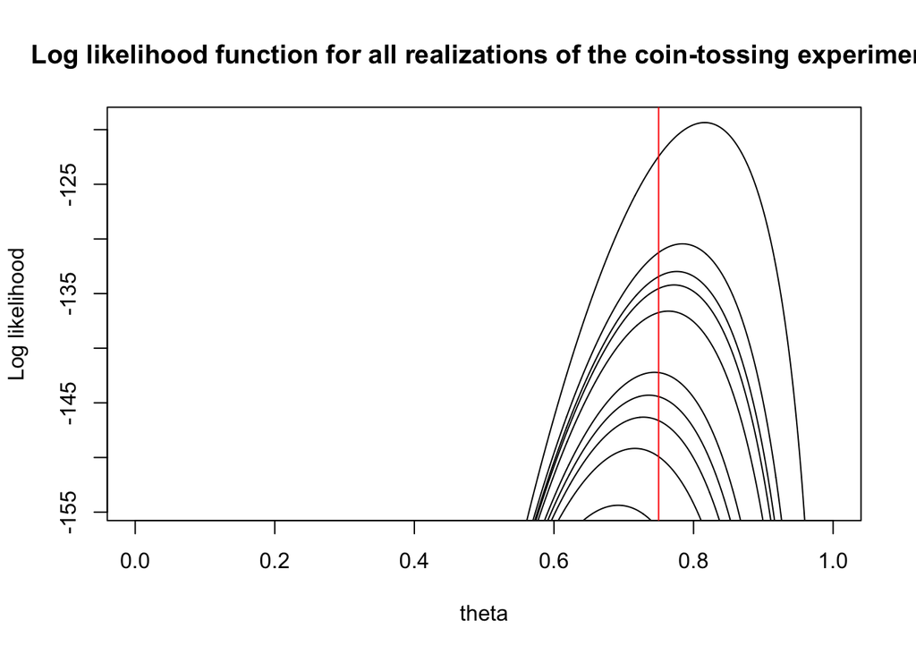

```r
# Grid of theta values
theta = seq(0, 1, by=0.001)
# Choose appropriate range of values for vertical axis
n1_interval = c(min(n_1), max(n_1)); th_hat_interval = n1_interval/n
maxL_interval = n*(th_hat_interval * log(th_hat_interval) + (1-th_hat_interval) * log(1-th_hat_interval))
# Create empty plot with axes and titles
plot(theta, theta,
     xlim=c(0,1), ylim=maxL_interval, type='n',
     main='Log likelihood function for all realizations of the coin-tossing experiment', xlab='theta', ylab='Log likelihood')
# Plot log-likelihood function for each realization of the experiment
for (i in 1:n_exper) {
  lines(theta, n_1[i] * log(theta) + n_0[i] * log(1-theta))
}
# Vertical line at true value
abline(v=theta_0, col='red')
```

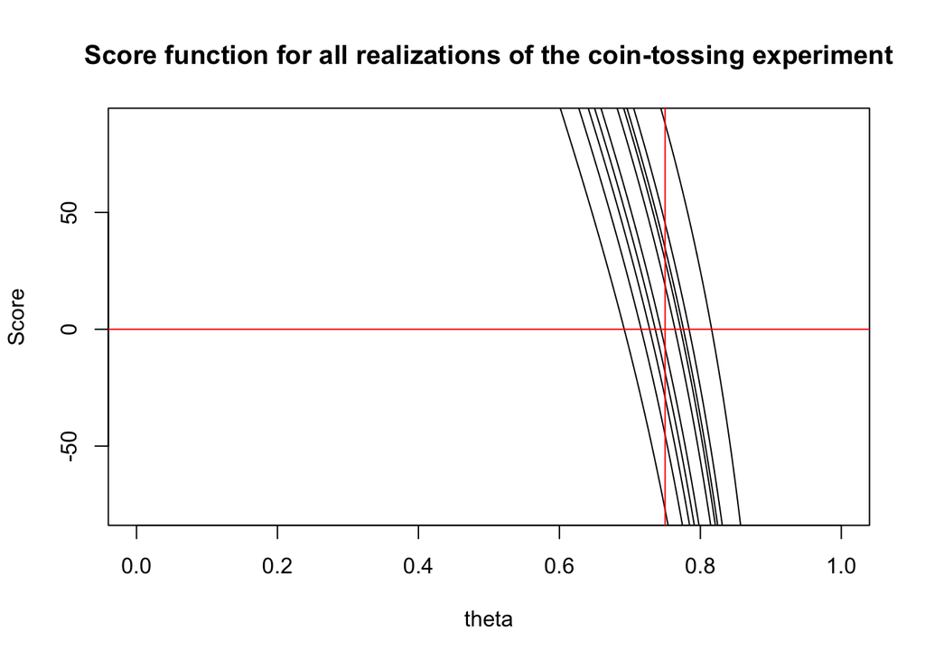

```r
score_interval = n1_interval / theta_0 - (n-n1_interval) / (1-theta_0)
plot(theta, theta, xlim=c(0,1), ylim=score_interval, type='n',
     main='Score function for all realizations of the coin-tossing experiment', xlab='theta', ylab='Score')
for (i in 1:n_exper) {
  lines(theta, n_1[i] / theta - n_0[i] / (1-theta))
}
# Vertical line at true value, horizontal line at zero
abline(v=theta_0, col='red')
abline(h=0, col='red')
```

Here are some qualitative observations on the variation in $L(\theta;x)$ and $s(\theta;x)$ in repeated samples.

1. The peak of the likelihood function occurs at a value $\hat\theta(X)$ that is sometimes greater than the true value $\theta_0$ (red line), sometimes less, depending on the experiment. Overall, the peaks appear centred near $\theta_0$.
2. The score at $\theta_0$, $s(\theta_0;X)$ is sometimes positive, sometimes negative, but appears centred near 0.

Corresponding to these observations, here are some exact quantitative results pertaining to the experiment.

1. The maximum likelihood estimator for this model is *unbiased*, meaning that its expected value is the true value of the parameter.
   $$E_{\theta_0}[\hat\theta] = \frac{\theta_0 n}{n} = \theta_0.$$
2. The expected score at $\theta_0$, for this model, is zero.
   $$E_{\theta_0}[s(\theta_0;x)] = \frac{\theta_0 n}{\theta_0} - \frac{(1-\theta_0)n}{1-\theta_0} = 0.$$

The first of these results is true for some models but not for many others. However, we will see later that there are still some things we can say about the central tendancy of $\hat\theta$ around $\theta_0$ that apply quite broadly. The second result holds more broadly, and there are some well known *regularity conditions* that are sufficient for the result; in practice, we can often verify these conditions for a particular model and then be confident that this result, and some others, hold.

The following exercise is for another one-parameter model. There are not many of these!

> Exercise: Suppose $X_i$, $i=1,\ldots,n$, are iid, each with a Poisson distribution with parameter $\lambda$. The true value of $\lambda$ is $\lambda_0$. Compute the likelihood, log-likelihood, score and Hessian functions. Find the maximum likelihood estimator $\hat\lambda$ and show that it is unbiased. Show that the expected score function is zero at the true value $\lambda_0$.

### Properties of maximum likelihood, as the number of observations grows

If we repeat the computational exercise with the same number of samples (experiments) but each with a larger sample size $n=1000$, we get the following log-likelihood functions.

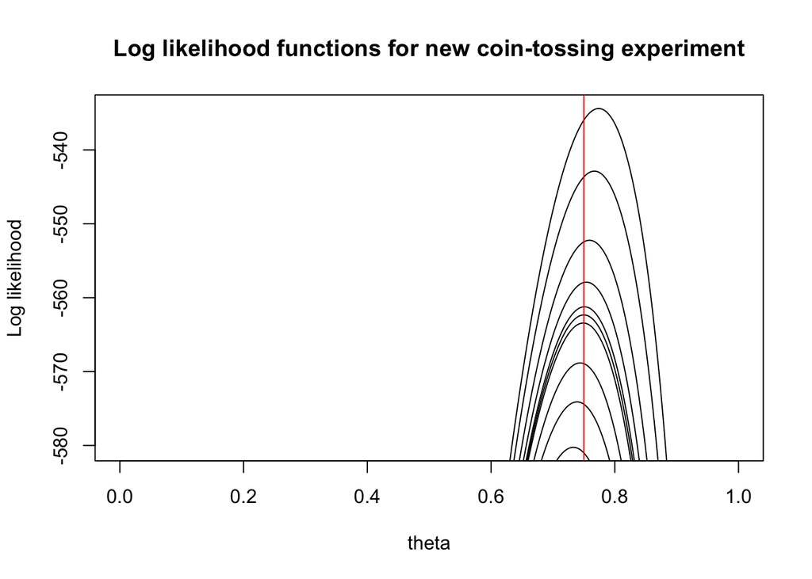

Some qualitative observations:

1. For the higher value of $n$, the values of $\hat\theta$ in repeated samples tend to be closer to the true value $\theta_0$.
2. Each likelihood function has more extreme curvature. The functions fall off faster as you go away from the maximizing value $\hat\theta$.

### A Gaussian likelihood

We now turn to a simple model with two parameters. The observables $X_i$, $i=1,\ldots$ are independent and identically distributed, with $X_i \sim N(\mu,\sigma^2)$, $i=1,\ldots,n$. The density of a single $X_i$ is
$$f(x_i) = \frac{1}{\sqrt{2\pi\sigma^2}}
\exp\left[-\frac{1}{2\sigma^2}(x_i-\mu)^2\right].$$
Thus the joint density of $X = (X_1,\ldots,X_n)$ is
$$f(x) = \prod_{i=1}^n \frac{1}{\sqrt{2\pi\sigma^2}}
\exp\left[-\frac{1}{2\sigma^2}(x_i-\mu)^2\right]
= (2\pi\sigma^2)^{-n/2} \exp\left[-\frac{1}{2\sigma^2}\sum_{i=1}^n (x_i-\mu)^2\right].$$
Each term of the sum in the exponential function is quadratic in $\mu$, with a negative coefficient of $\mu^2$. Therefore the sum itself is quadratic in $\mu$, with a negative coefficient of $\mu^2$.

Now we can use the identity to write the joint density of $f(x)$ as
$$f(x) = \prod_{i=1}^n \frac{1}{\sqrt{2\pi\sigma^2}}
\exp\left[-\frac{1}{2\sigma^2}(x_i-\mu)^2\right]
= (2\pi)^{-n/2} (\sigma^2)^{-n/2} \exp\left[-\frac{S + n (\bar x - \mu)^2}{2\sigma^2}
\right],$$
where $S = \sum_{i=1}^n (x_i-\mu)^2$.

Defining $\theta = (\mu, \sigma^2)$, the log likelihood function is
$$L(\theta;x) = -\frac{n}{2} \log 2\pi\sigma^2 - \frac{S + n (\bar x - \mu)^2}{2\sigma^2}.$$
It is easy to see that for every value of $\sigma^2$, $\hat \mu = \bar x$ gives the largest value of $L(\theta; x)$. Setting $\mu = \bar x$ in $L(\theta; x)$ gives a univariate function of $\sigma^2$ that is easier to maximize.

> Exercise: show that $\hat\theta = (\bar x, S/n)$ maximizes the log likelihood function.